# Attempt1_filesubmission_Avneesh Mishra - Wheel Encoders and Drift

```python
import pandas as pd
import numpy as np
import matplotlib.pyplot as plt
from IPython.display import Image
%matplotlib inline
```

You could mount Google Drive folder to this notebook (if running remotely). Reference post on a [towardsdatascience](https://towardsdatascience.com/downloading-datasets-into-google-drive-via-google-colab-bcb1b30b0166) blog. If you're running through local system, you could use the path on your local system.

```python
!ls -R
```

```
data

./data:
ground_truth.csv   wheel_control.csv  wheel_encoders.png
```

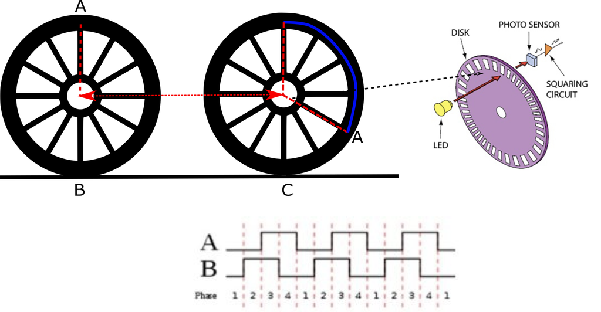

```python
wheel_encoders_img_path = "./data/wheel_encoders.png"
Image(wheel_encoders_img_path)
```

In a differential-drive model, we discussed the relation between wheel velocities and robot's rotational and translational velocity, i.e, $v, \omega$.

If we need to know curent $v, \omega$ how to measure wheel velocities? We use wheel encoders

Encoder resolution = $N$

Every $\Delta T$ ms,

- Encoder reports # ticks wheel moved = $n$
- Angle moved = $2\pi \frac{n}{N}$

Usage

- Smallest movement that can be measured is $\frac{2\pi}{N}$ radians
- Largest speed that can be measured is $\frac{2\pi}{\Delta T}$

Pros:

- Fairly accurate estimates of linear/ angular velocity
- Distances and rotations are accurate in short-term

Cons:

- Vehicle position “drifts” when $v,\omega$ is integrated over longer periods

Say, your robot's initial pose is (0.0, 0.0, 0.0), write a program to accept left and right ticks as input and output the next pose

Assume an unicycle model and following vehicle parameters

- Wheel radius ($r$) = 2.0m
- Track-width ($L$) = 4.0m
- Encoder ticks ($N$) = 100
- Encoder frequency ($\Delta T$) = 0.1

Test your code with $n_{right} = 10$ and $N_{left} = 6$. Do you get the next pose as $(1.0053, 0.0, 0.1257)$?

```python
def get_vw_from_encoder(nl, nr, N=100, L=4.0, r=2.0, dt=0.1):
    dtheta_left = (2*np.pi / N) * nl
    dtheta_right = (2*np.pi / N) * nr
    wl = dtheta_left / dt
    wr = dtheta_right / dt
    v = r * (wr + wl) / 2
    w = (r / L) * (wr - wl)
    return (v, w)
```

Our older unicycle model

```python
def unicycle_model(curr_pose, v, w, dt=0.1):
    x, y, theta = curr_pose
    x_new = x + v * np.cos(theta) * dt
    y_new = y + v * np.sin(theta) * dt
    theta_new = theta + w * dt
    # Keep theta bounded between [-pi, pi]
    theta = np.arctan2(np.sin(theta), np.cos(theta))
    return x_new, y_new, theta_new
```

Get new pose, given the older pose is (0.0, 0.0, 0.0)

```python
v, w = get_vw_from_encoder(6, 10)
curr_pose = (0, 0, 0)
next_pose = unicycle_model(curr_pose, v, w)
print(f"Next pose is: {next_pose}") # We get the next point as (x, y, theta)
```

```
Next pose is: (1.0053096491487339, 0.0, 0.12566370614359174)
```

### Effect of angular error in pose estimate

First, model to give estimates

```python
def unicycle_model(curr_pose, v, w, dt=0.1):
    x, y, theta = curr_pose
    x_new = x + v * np.cos(theta) * dt
    y_new = y + v * np.sin(theta) * dt
    theta_new = theta + w * dt
    # Keep theta bounded between [-pi, pi]
    theta = np.arctan2(np.sin(theta), np.cos(theta))
    return x_new, y_new, theta_new
```

Initial conditions

```python
time_vals = np.arange(0, 30, 0.1)   # dt = 0.1, 0 to 30 seconds
all_v = np.ones_like(time_vals) * 2 # 2 m/s throughout
all_w = np.zeros_like(all_v)    # No angular velocity (straight line)
```

Values with $1^{\circ}$ error

```python
initial_error = np.deg2rad(1.0) # 1 degree initial error
robot_path_error = []
robot_pose_error = np.array([0, 0, np.pi/2 + initial_error])
robot_path_error.append(robot_pose_error)
for v, w in zip(all_v, all_w):
    robot_pose_error = unicycle_model(robot_pose_error, v, w)
    robot_path_error.append(robot_pose_error)
robot_path_error = np.array(robot_path_error)
```

Values with no error

```python
robot_path = []
robot_pose = np.array([0, 0, np.pi/2])
robot_path.append(robot_pose)
for v, w in zip(all_v, all_w):
    robot_pose = unicycle_model(robot_pose, v, w)
    robot_path.append(robot_pose)
robot_path = np.array(robot_path)
```

```
Deviation of -1.0471443862370093 m in X direction
Tan(theta_error) * Yval = 1.0473038956930605
```

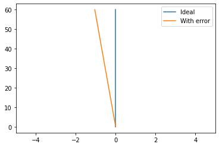

```python
# Plot values
plt.figure()
plt.plot(robot_path[:, 0], robot_path[:, 1])
plt.plot(robot_path_error[:, 0], robot_path_error[:, 1])
plt.xlim(-5, 5)
plt.legend(['Ideal', 'With error'])
x_error = robot_path_error[-1, 0] - robot_path[-1, 0]
print(f"Deviation of {x_error} m in X direction")
# Another way of calculating error
x_error2 = np.tan(initial_error) * robot_path[-1, 1]
print(f"Tan(theta_error) * Yval = {x_error2}")
```

If there was no initial angle error, robot will end up at $x$ = 0.0.

Plot a graph between initial_error and final $x$ position?

```python
# A function to run the simulation and return the error
def ret_final_deviation_with_init_error(init_error, all_v, all_w, dt_val = 0.1):
    ie = np.deg2rad(init_error) # Convert error to radians
    robot_pose_error = np.array([0, 0, np.pi/2 + ie])   # Initial pose with error
    robot_path_error = [robot_pose_error]   # Starting the path (with error)
    robot_pose = np.array([0, 0, np.pi/2])  # Initial pose (no error)
    robot_path = [robot_pose]   # Starting the path (no error)
    for v, w in zip(all_v, all_w):
        # Error
        robot_pose_error = unicycle_model(robot_pose_error, v, w, dt_val)
        robot_path_error.append(robot_pose_error)
        # True pose (without error)
        robot_pose = unicycle_model(robot_pose, v, w, dt_val)
        robot_path.append(robot_pose)
    robot_path_error = np.array(robot_path_error)
    robot_path = np.array(robot_path)
    x_diff = robot_path[-1, 0] - robot_path_error[-1, 0]
    y_diff = robot_path[-1, 1] - robot_path_error[-1, 1]
    theta_diff = robot_path[-1, 2] - robot_path_error[-1, 2]
    # Return the final differences and the robot path
    return (x_diff, y_diff, theta_diff, robot_path, robot_path_error)
```

Calculate the X errors for different initial error values

```python
init_errors = np.arange(-180, 180, 1)   # -180 to 180, 1 deg step
# Experiment parameters
time_vals = np.arange(0, 30, 0.1)   # dt = 0.1, 0 to 30 seconds
all_v = np.ones_like(time_vals) * 2 # 2 m/s throughout
all_w = np.zeros_like(all_v)    # No angular velocity (straight line)
x_errors = []
for init_error in init_errors:
    # Get dx, dy, dz only (no need of paths)
    dx, dy, dth, _, _ = ret_final_deviation_with_init_error(init_error, all_v, all_w)
    x_errors.append(dx)
x_errors = np.array(x_errors)
```

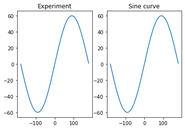

```python
# Plot it
plt.figure()
plt.subplot(121)
plt.title("Experiment")
plt.plot(init_errors, x_errors)
# Compare with sine curve of the distance and angle
plt.subplot(122)
plt.title("Sine curve")
dist = 2 * time_vals[-1]    # Speed * time
plt.plot(init_errors, dist * np.sin(np.deg2rad(init_errors)))
```

### Demonstrate localization drift in wheel encoders

Get the path generator function

```python
def get_open_loop_commands(route, vc=1, wc=np.pi/12, dt=1.0):
    all_w = np.array([])
    ang_speed = {
        "straight": 0.0,
        "left": wc,
        "right": -wc
    }
    for (command, value) in route:
        if (command in ["left", "right"]):
            value = np.deg2rad(value)
        time_cmd = value / (vc if command == "straight" else wc)
        t_val = int(np.ceil(time_cmd))
        all_w = np.append(all_w, [ang_speed[command]] * t_val)
    all_v = vc * np.ones_like(all_w)
    return all_v, all_w
```

Properties of path

- [("straight", 5), ("right", 90), ("straight", 6), ("left", 85)]
- $v_c = 1$
- $w_c = \pi/12$

```python
all_v, all_w = get_open_loop_commands([("straight", 5), ("right", 90), ("straight", 6), ("left", 85)])
```

```python
_, _, _, robot_path, robot_path_error = ret_final_deviation_with_init_error(
    10, all_v, all_w, 1.0    # 10 deg init error, 1 sec dt
)
```

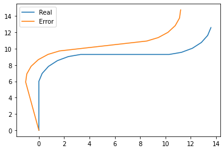

```python
# Plot both paths
plt.figure()
plt.plot(robot_path[:, 0], robot_path[:, 1])
plt.plot(robot_path_error[:, 0], robot_path_error[:, 1])
plt.legend(['Real', 'Error'])
```

### Synthetic dataset

```python
all_v = np.ones(100)
all_w = np.zeros(100)
```

```python
robot_traj, robot_traj_noisy = [], []
ideal_pose = np.array([0, 0, np.pi/2])
noisy_pose = np.array([0, 0, np.pi/2])
robot_traj.append(ideal_pose)
robot_traj_noisy.append(noisy_pose)
for v, w in zip(all_v, all_w):
    robot_traj.append(ideal_pose)
    robot_traj_noisy.append(noisy_pose)
    #code to update ideal_pose
    ideal_pose = unicycle_model(ideal_pose, v, w)
    robot_traj.append(ideal_pose)
    #code to update noisy pose
    #add gaussian noise with std dev of 0.01 to omega
    nx, ny, nth = unicycle_model(noisy_pose, v, w)
    noisy_pose = (nx, ny, (nth + np.random.normal(0, 0.01)))
    robot_traj_noisy.append(noisy_pose)
robot_traj = np.array(robot_traj)
robot_traj_noisy = np.array(robot_traj_noisy)
```

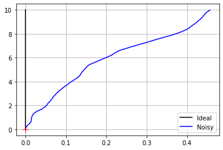

```python
plt.figure()
plt.grid()
# plt.axes().set_aspect("equal","datalim")
plt.plot(robot_traj[:,0], robot_traj[:,1],'k-')
plt.plot(robot_traj_noisy[:,0], robot_traj_noisy[:,1],'b-')
plt.plot(0, 0, 'r+', ms=10)
plt.legend(['Ideal', 'Noisy'])
```

### Real dataset

Using the local runtime, so the paths are different

```python
ground_truth_path = "./data/ground_truth.csv"
wheel_control_path = "./data/wheel_control.csv"
```

```python
ground_truth = pd.read_csv(ground_truth_path)
gt_traj = np.array(ground_truth[['x','y']]) # True x, y values (no change to this)
# When wheel_enc is assumed to have been derived through the encoder values on the system
# v and w here are therefore noisy (accomodate for the noise of encoders)
wheel_enc = np.array(pd.read_csv(wheel_control_path)[['v','w']])    # Commands
```

```python
def unicycle_model(pose, v, w, dt = 0.01):
  x, y, theta = pose
  x += v*np.cos(theta)*dt
  y += v*np.sin(theta)*dt
  theta += w*dt
  theta = np.arctan2(np.sin(theta), np.cos(theta))
  return x, y, theta
```

```python
pose = np.array(ground_truth[['x','y','theta']])[0] #initial pose
robot_traj = [pose]
for v, w in wheel_enc:
    # code for updating pose
    pose = unicycle_model(pose, v, w)
    robot_traj.append(pose)
robot_traj = np.array(robot_traj)
```

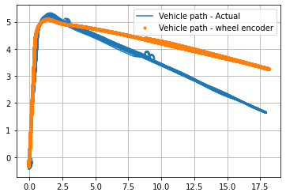

```python
end = 10000
plt.figure()
plt.grid()
plt.plot(gt_traj[:,0], gt_traj[:,1], label='Vehicle path - Actual')
plt.plot(robot_traj[:end,0], robot_traj[:end,1], '.', label='Vehicle path - wheel encoder')
plt.legend()
```